# Resultados da Primeira Avaliación IES Muralla Romana. Curso 2021-2022.

Nestas gráficas amósanse para cada clase, trimestre e categorías (resultados académicos) as porcentaxes.

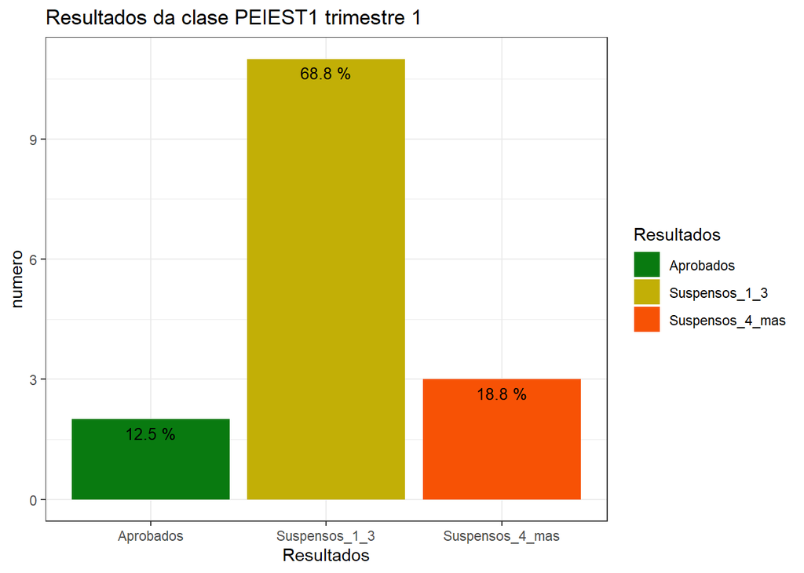

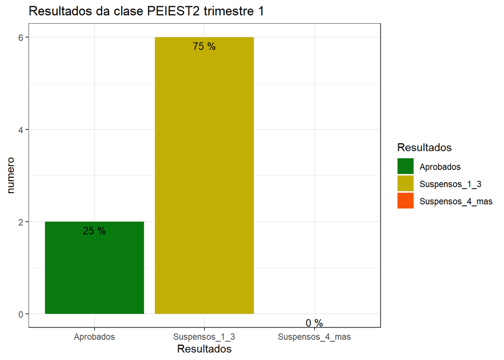

**A porcentaxe de alumnos de INFOFI que aprobaron todas as materias no 1º Trimestre foi do 47.8%, o 34.8% suspenderon entre 1 e 3 materias, e o 17.4% 4 ou mais materias.**

**Para o caso dos alumnos de PEIEST a porcentaxe dos alumnos que aprobaron todas as materias foi do 16.7%, o 70.8% suspenderon entre 1 e 3 materias, e o 12.5% 4 ou mais materias.**

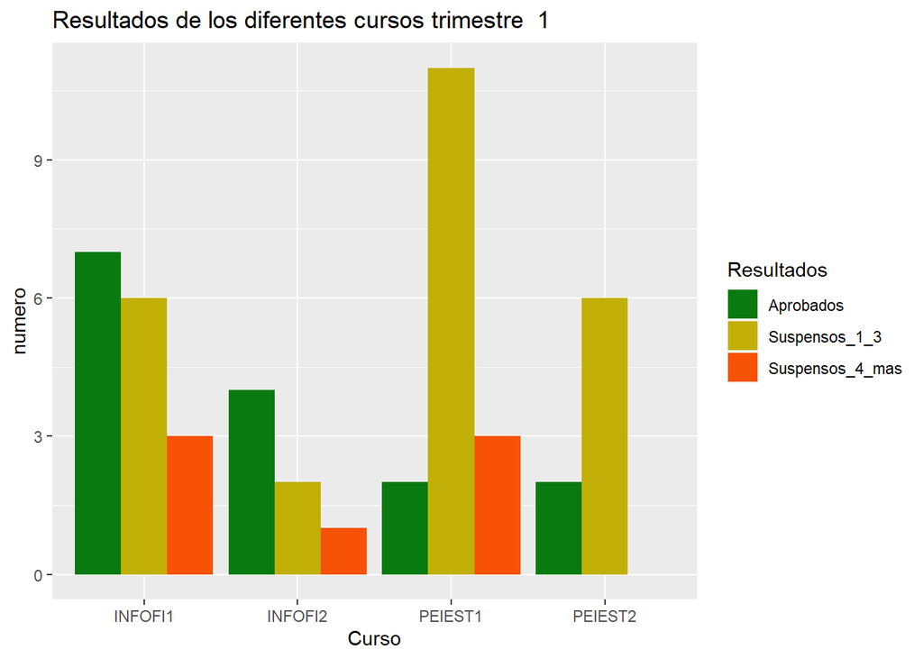

## 4.1 Gráficos para as clases de INFOFI

Nestes gráficos amósanse para cada clase, trimestre e categorías (resultados académicos) as porcentaxes.

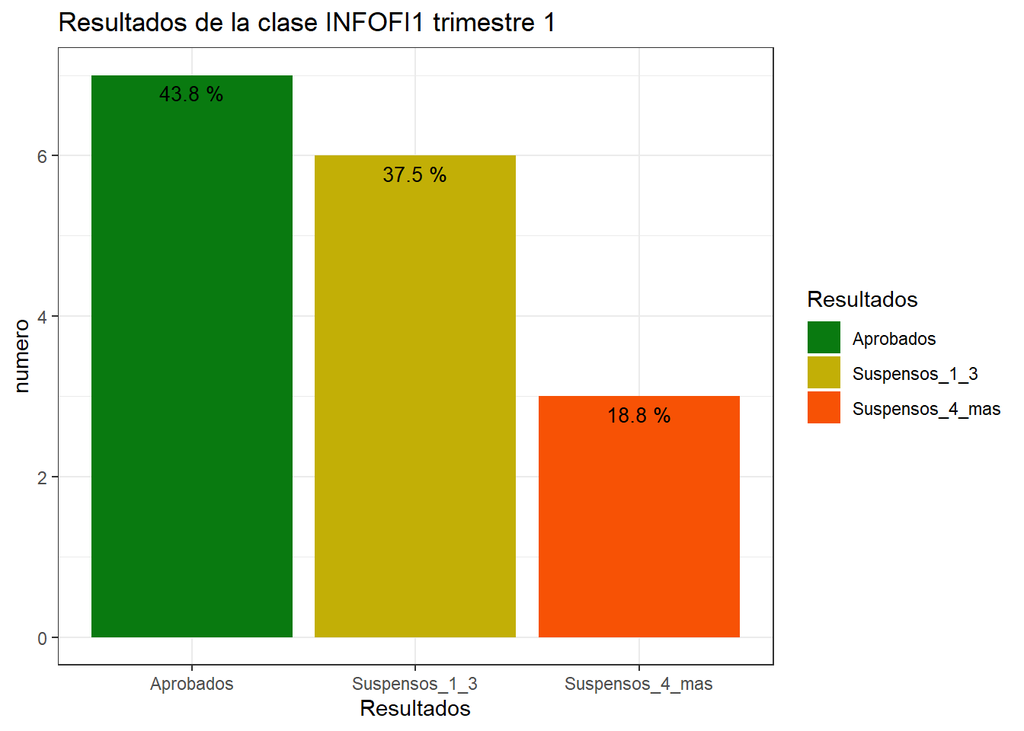

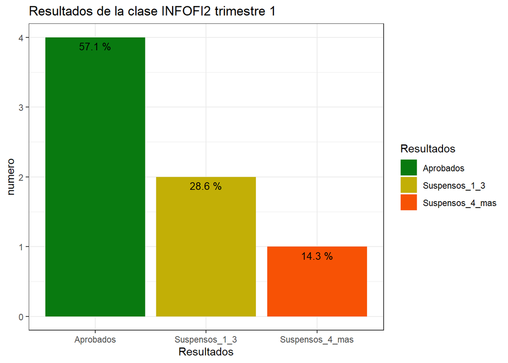

## 4.2 Gráficos para as clases de PEIEST

Nestes gráficos amósanse para cada clase, trimestre e categorías (resultados académicos) as porcentaxes.

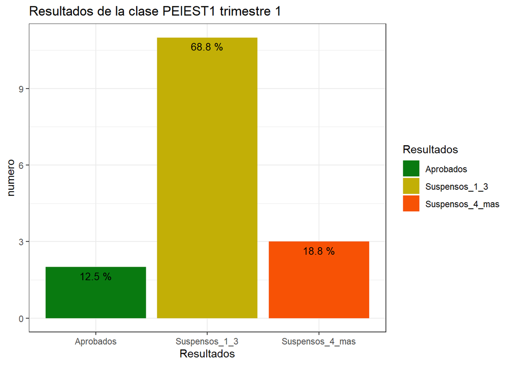

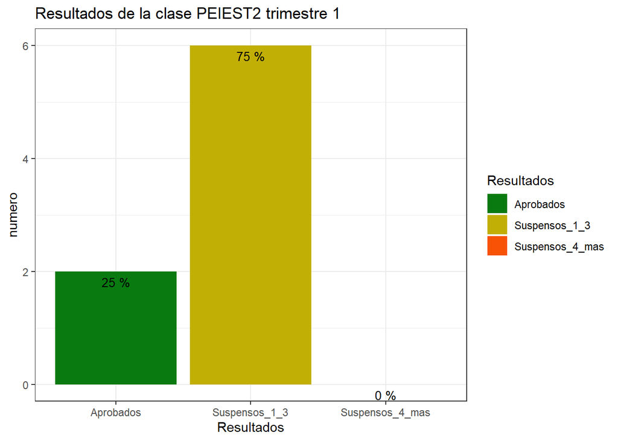

# 5 Gráficos cos datos por trimestres e resultados para INFOFI e PEIEST

Nestes gráficos amósanse o número de alumnos por clase e trimestre distribuídos por resultados académicos nun diagrama de barras.

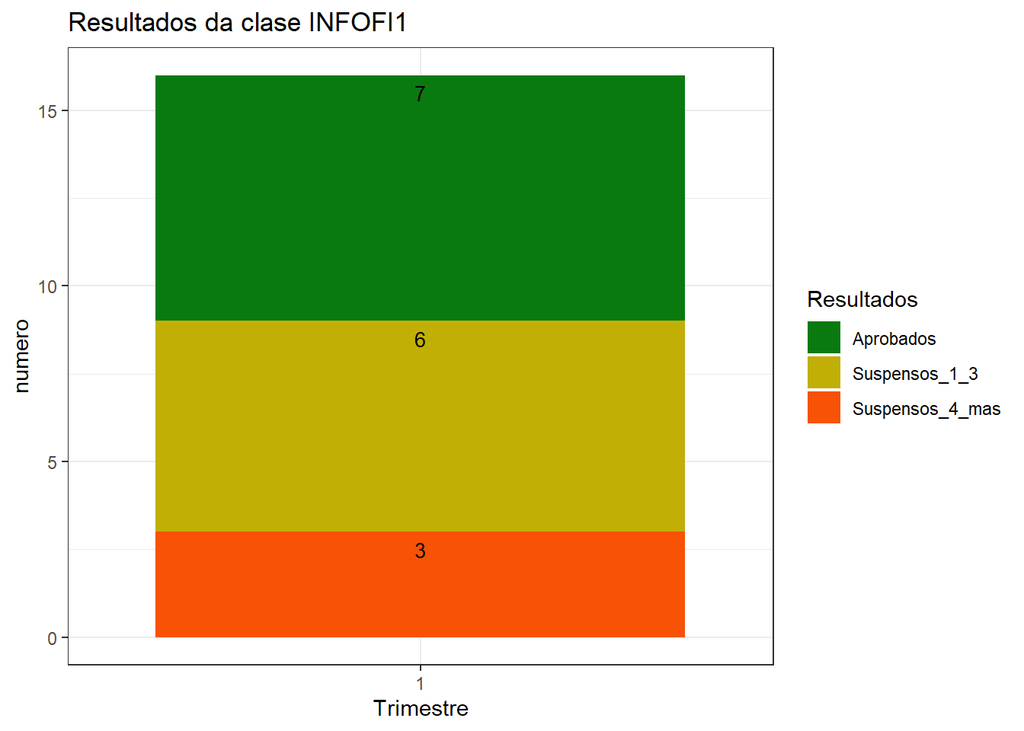

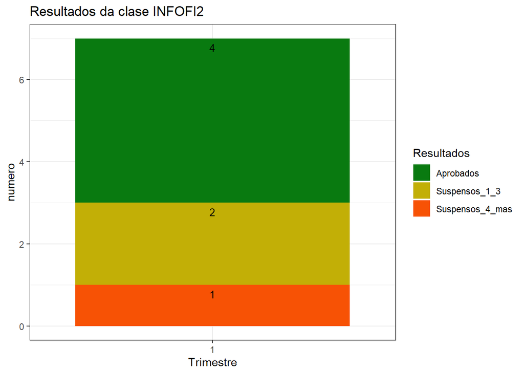

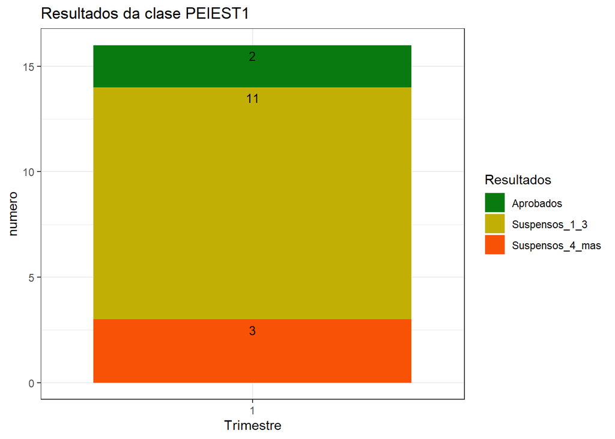

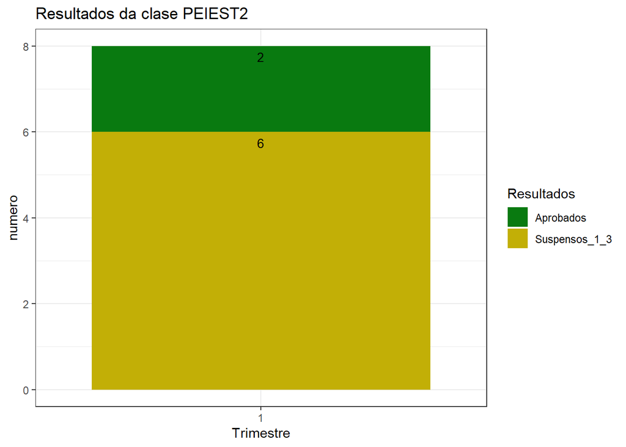